# West Bengal Assembly Election Outcomes

Onkar Singh

2021-05-10

## Reading data

West Bengal Assembly election was one of the most keenly watched Assembly election in any Indian state. One of the reasons for this interest was unexpected rise of Bharatiya Janata Party in a state mostly known for its contests between the Left and the Trinmool Congress. The BJP had only 3 seats in the last Assembly election of 2016 whereas the ruling TMC had 212. BJP was never a major player in state expect during the last Parliamentary election where BJP bagged 18 of the 42 parliament seats. This rasied a very high hopes in the saffron camp and they put all their political might in the recently concluded West Bengal Legislative Assembly election where it was pitted against the ruling TMC lead by firebrand leader Mamta Banerjee. The stakes were so high that BJP made some of its central ministers resign to contest the assembly elections to bolster party chances in the state traditionally considered home to the non-BJP political forces. This was copuled with the high decibal election campaingn lead by the Prime Minister Narendra Modi, along with Home Minister Amit Shah and BJP President JP Nadda. On the other hand, Two time chief minister Mamata Banerjee led the incumbent party from the front and ran a highly successful campaingn leading to her party’s victory in the Assembly Election. This marked the begginning of the third term of the TMC government in the State.

While the BJP ran the campaign targeting 200 seats, the TMC’s poll strategist Prashant Kishor was so confident that he declared if BJP crossed the 100 seats he would leave his role as political advisor.

The opinion and exit polls were equally divided some giving edge to the ruling TMC while other giving slight edge to the BJP. However, the final results on 2nd May 2021, put all speculations to rest with TMC winning 213 of the seats, whereas BJP managed to win only 77 seats.

This paper analyzes the election results data obtained from Election Commission of India and Ashoka University.

## Total Number of Political Parties in the Fray

Total Number of Political Parties in the Election)

| party | number_of_seats_contested |
| --- | --- |
| IND | 611 |
| BJP | 291 |
| AITC | 288 |
| SUCI | 188 |
| BSP | 162 |
| CPM | 138 |
| INC | 91 |
| Bahujan Mukti Party | 45 |
| Amra Bangalee | 40 |
| RSSCMJP | 32 |
| AIFB | 21 |
| JD(U) | 16 |
| Kamatapur People’s Party (United) | 15 |
| CPI(ML)(L) | 12 |
| Purvanchal Mahapanchayat | 12 |
| CPI | 10 |
| LJP | 10 |
| RSP | 10 |
| Bharatiya Nyay-Adhikar Raksha Party | 8 |
| Justice and Development Party, | 7 |
| Party for Democratic Socialism | 7 |
| AIMIM | 6 |
| United Socialist Party | 6 |
| Bahujan Maha Party | 5 |
| Indian Unity Centre | 5 |
| Republican Party of India (A) | 5 |
| Ambedkarite Party of India | 4 |
| IUML | 4 |
| Jan Sangh Party | 4 |
| National Republic Party Of India | 4 |
| Republican Party of India (Athawale) | 4 |
| SDPI | 4 |
| Socialist Party (India) | 4 |
| Welfare Party Of India | 4 |
| Communist Party of India (Marxist-Leninist) Red Star | 3 |
| Democratic Socialist Party of India | 3 |
| HAM | 3 |
| Humanity Universal Motion Party | 3 |
| NPP | 3 |
| Akhil Bharat Hindu Mahasabha | 2 |
| All India Minorities Front | 2 |
| Bharatiya Momin Front | 2 |
| Bhartiya Tribal Party | 2 |
| Guru Chand Mukti Morcha | 2 |
| Mulnibasi Party of India | 2 |
| Right to Recall Party | 2 |
| West Bengal Socialist Party | 2 |
| AJSUP | 1 |
| Bharateeya Manavadhikar party | 1 |
| Jamat-E-Seratul Mustakim | 1 |
| Lok Samya Party | 1 |
| New Democratic Party of India | 1 |
| Paradise Party | 1 |
| Progressive People's Party | 1 |
| Rashtravadi Janata Party | 1 |
| Revolutionary Socialist Party of India(Marxist) | 1 |
| Sajag Samaj Party | 1 |
| Samajwadi Jan Parishad | 1 |
| Vikas India Party | 1 |

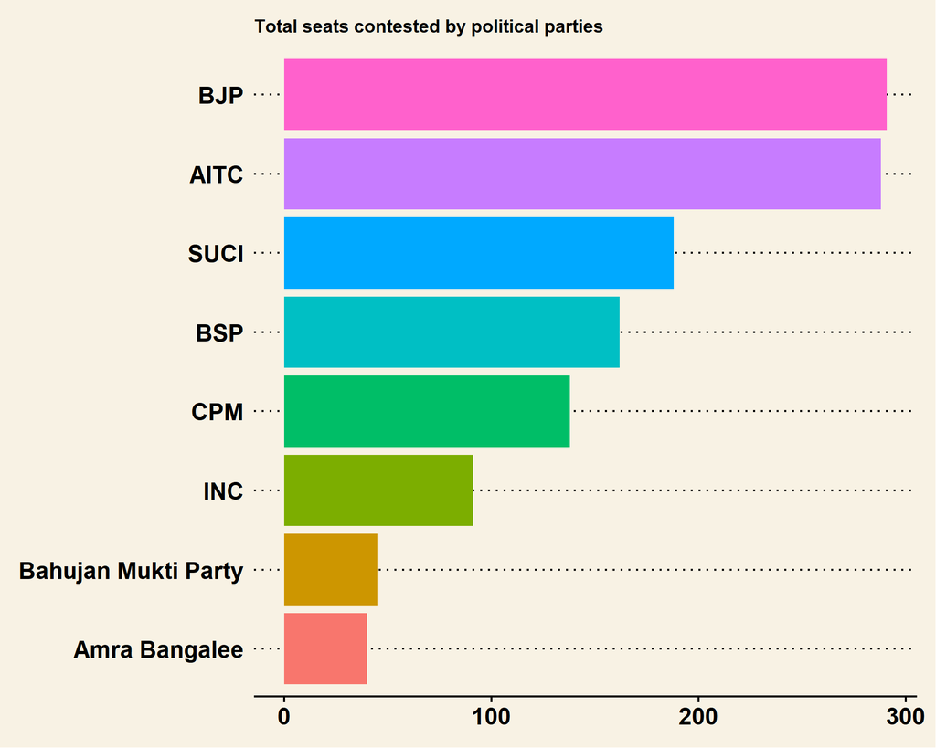

## Total number of turncoats fielded by each political party

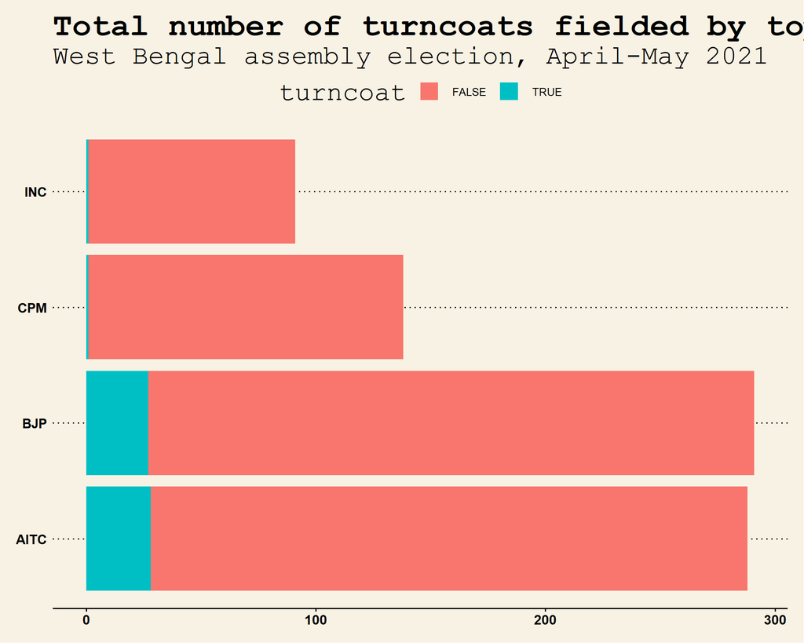

## Total number of repeat political party

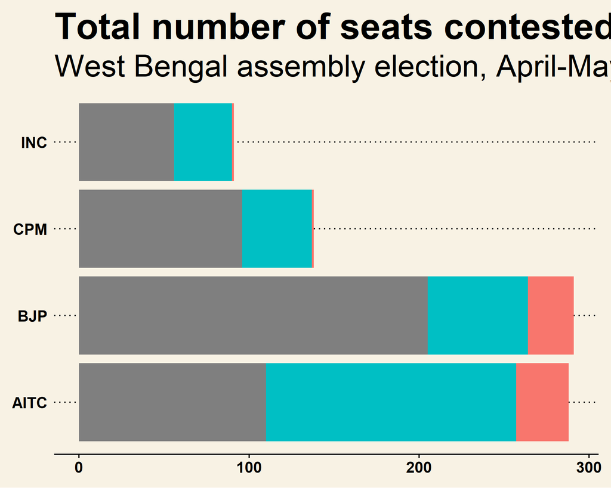

## Total number of repeat constituency by candiates

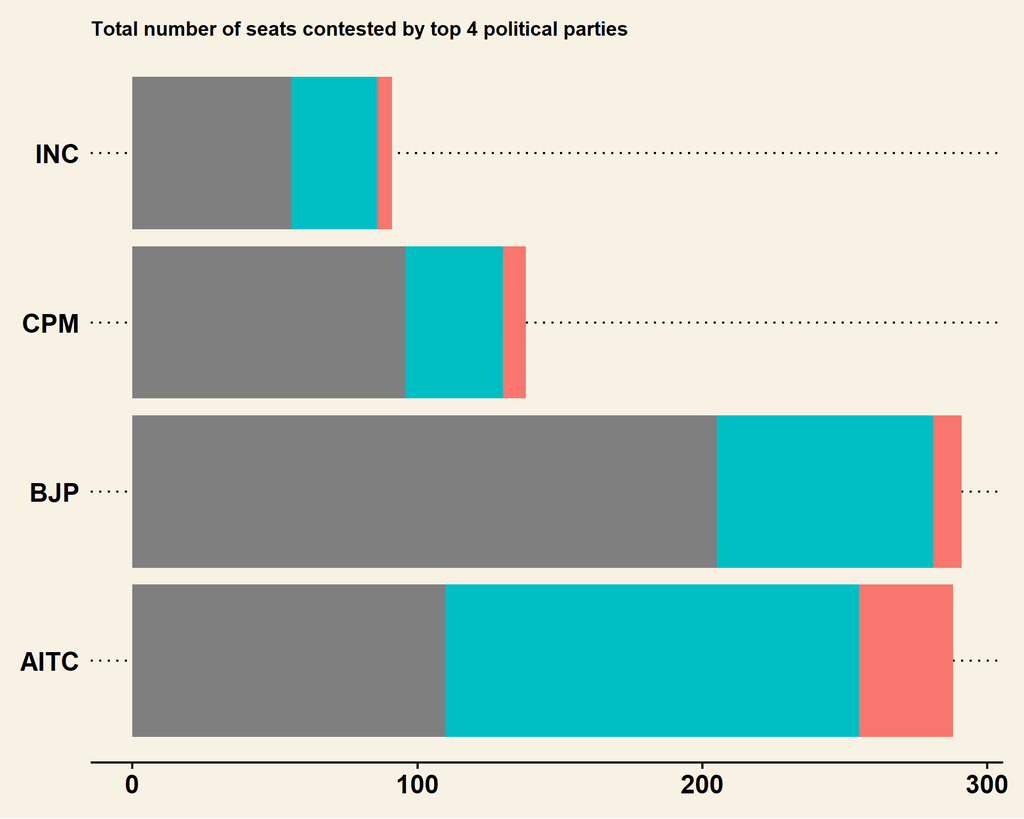

## Total number of repeat candidates

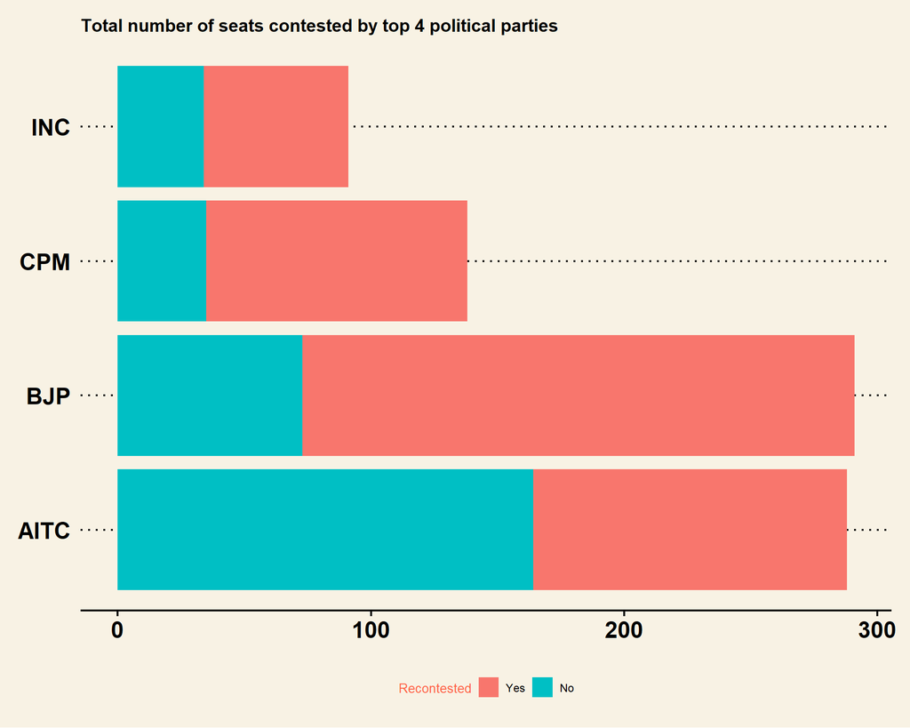

## Total number of incumbents

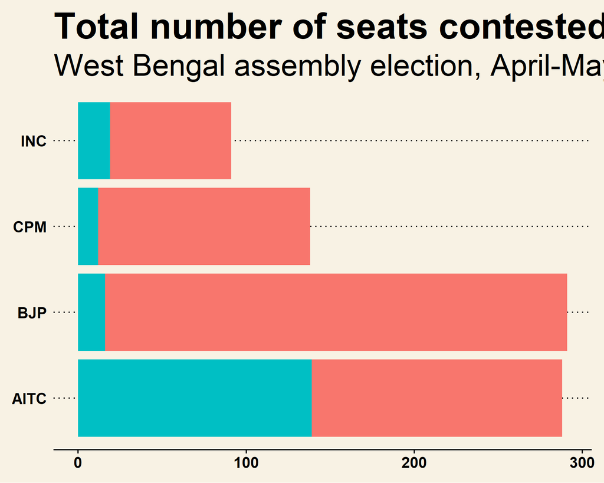

## Total number of Votes secured by each political party

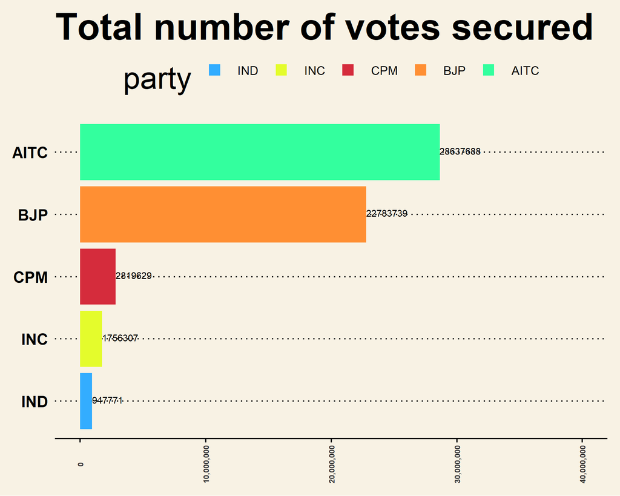

## Total percentage of Votes secured by each political party

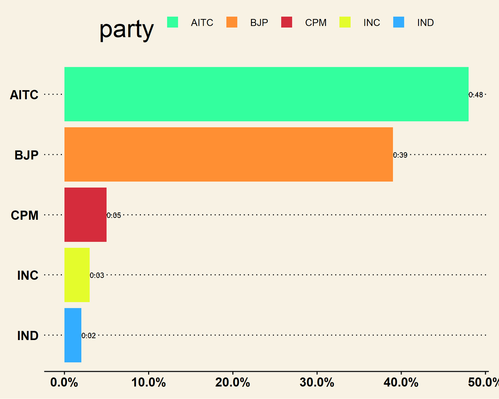

## Total number of seats secured by each political party

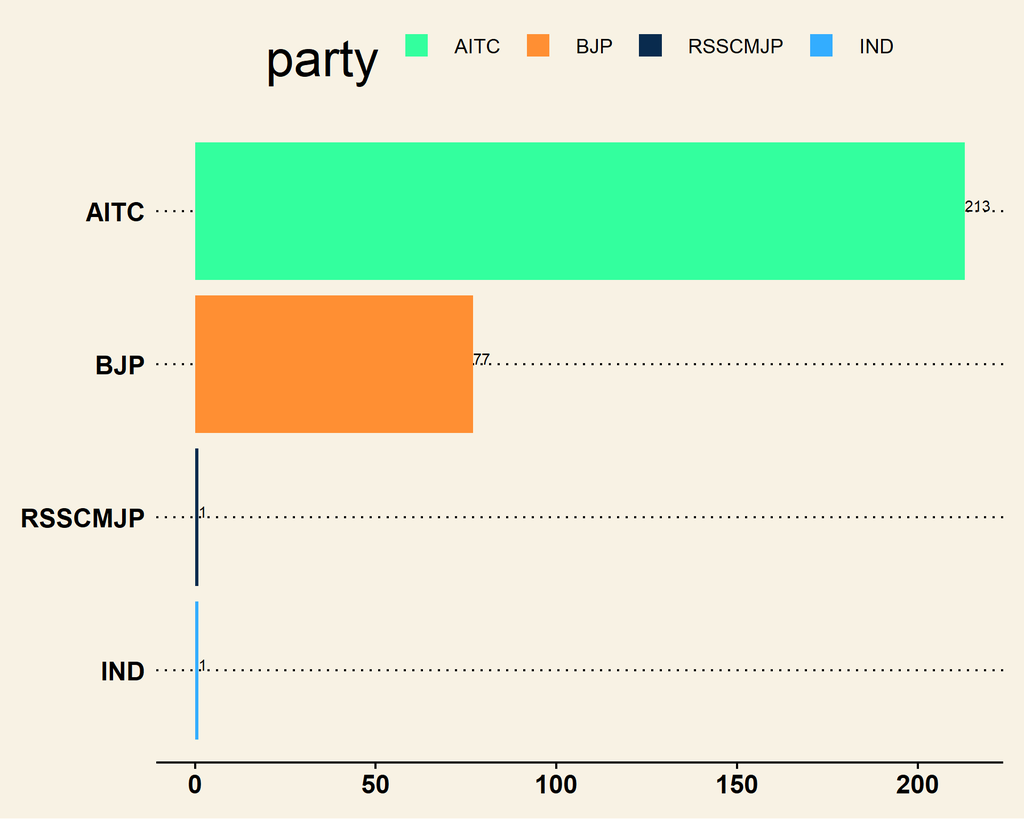

## Total number of seats secured by each political party by region

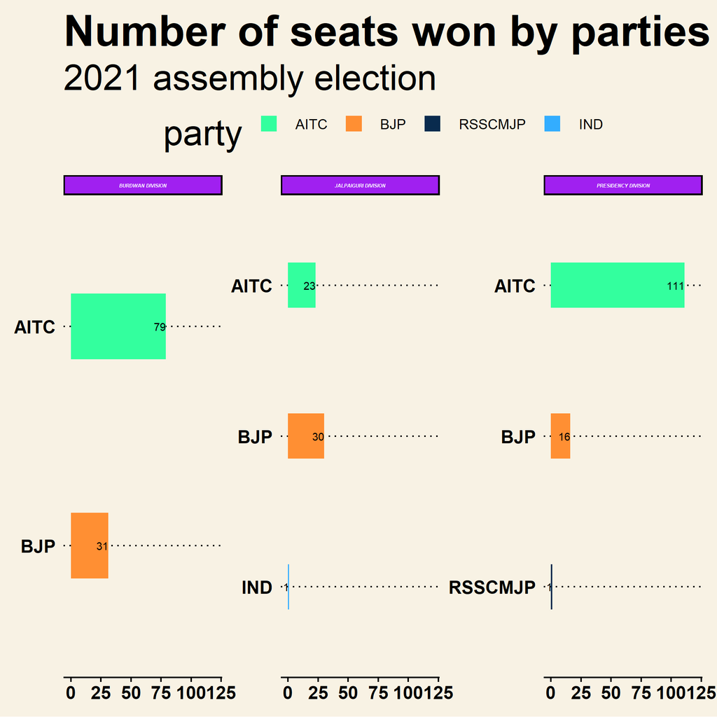

## Total number of seats secured by each political party by district

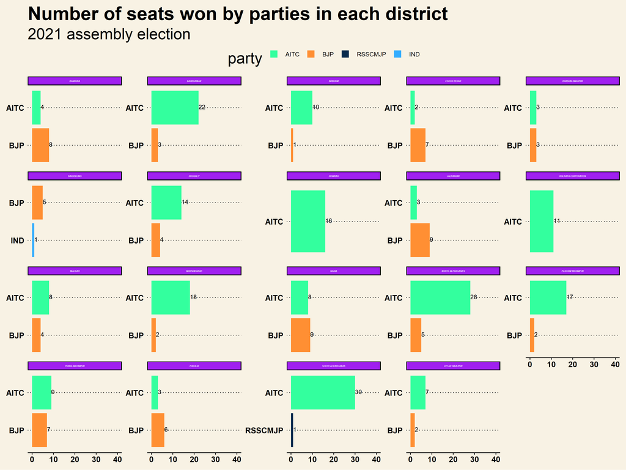

## Has the voters rewarded the turncoats

[figure not shown]

## Gender split of Winner candidates by party

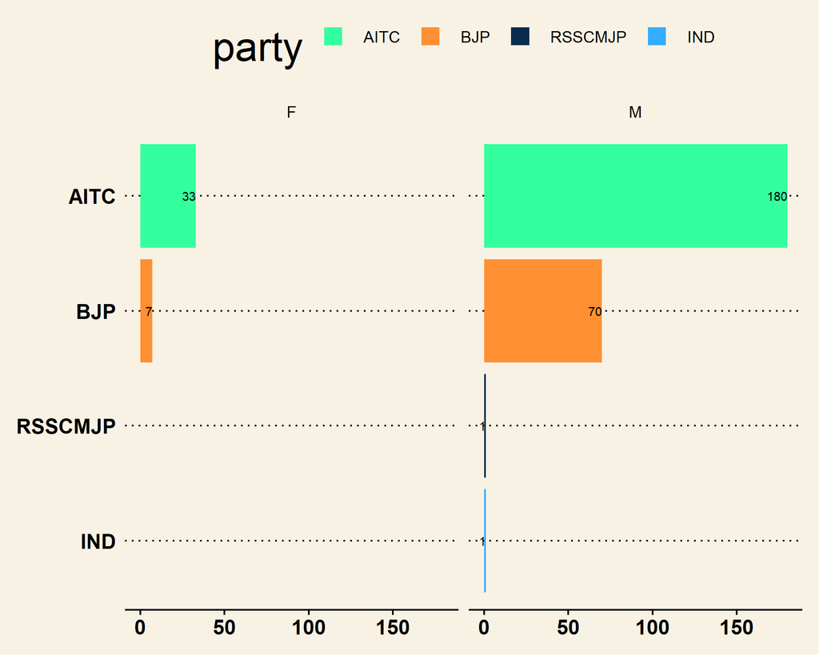

## Winner by consituency type

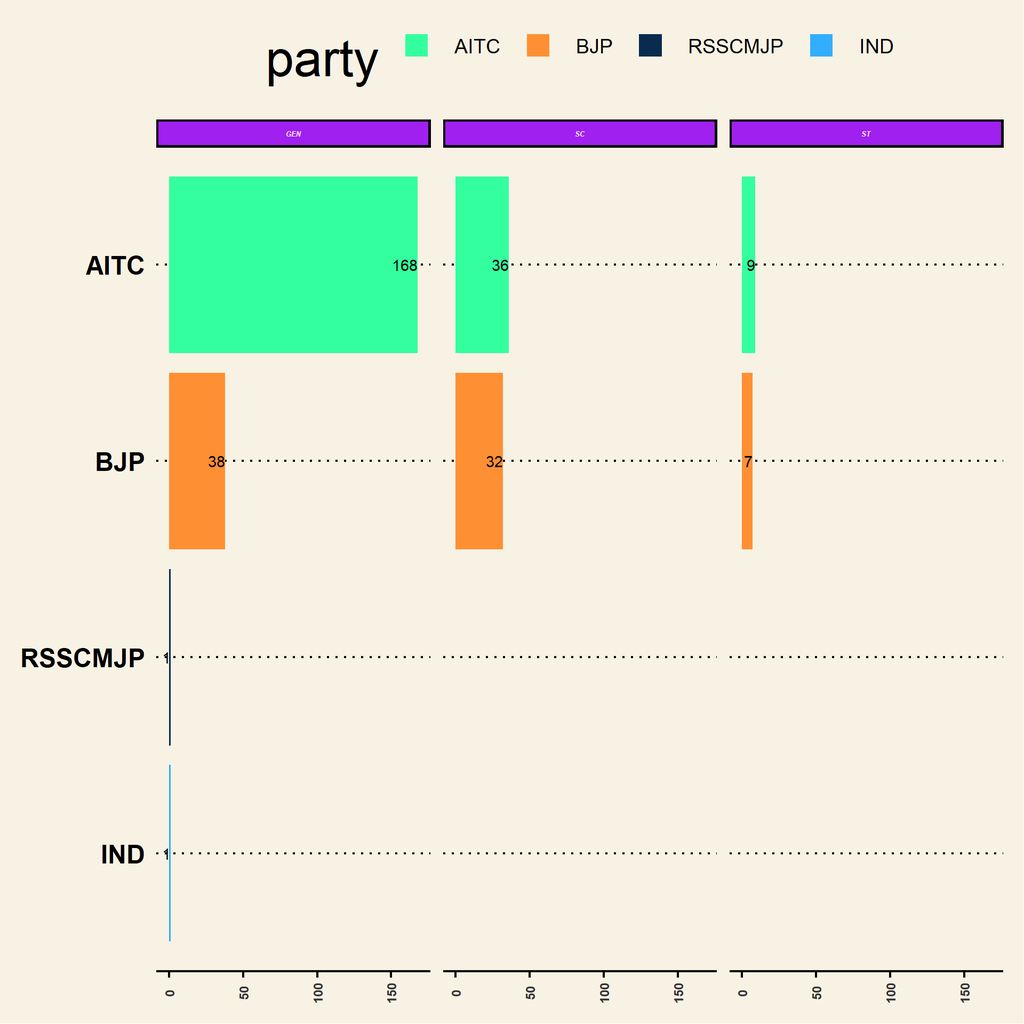

## Winner by margin of 1000 or less

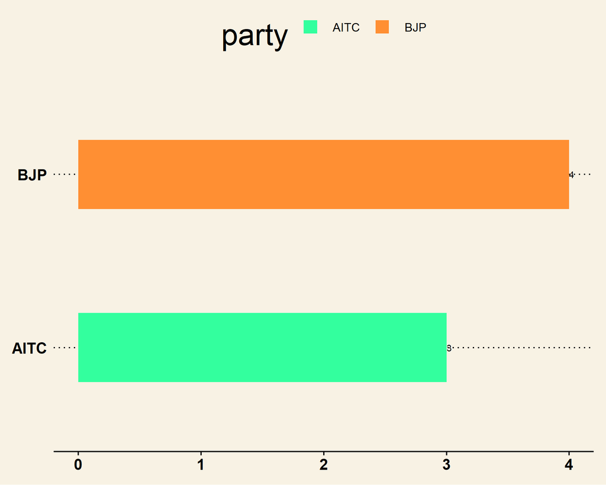

### Distribution of Candidates Age by Sex

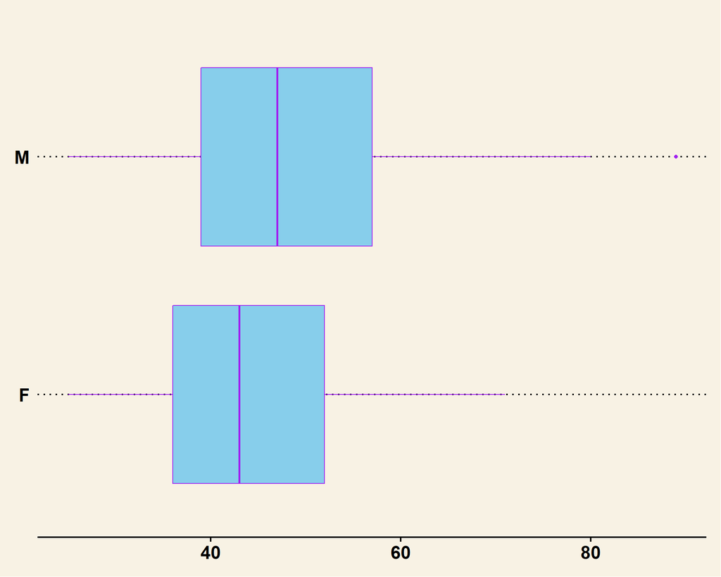

## Distribution of Voting percentage by constituency type

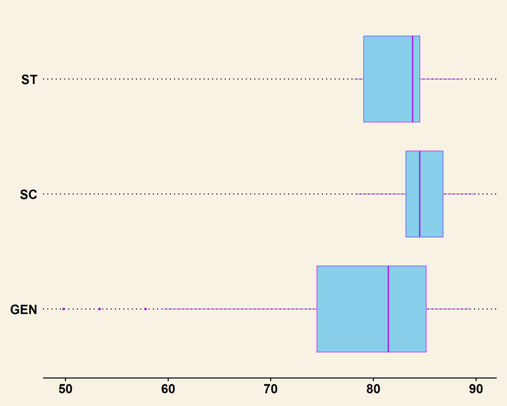

## Distribution of Voting percentage by Sub Region

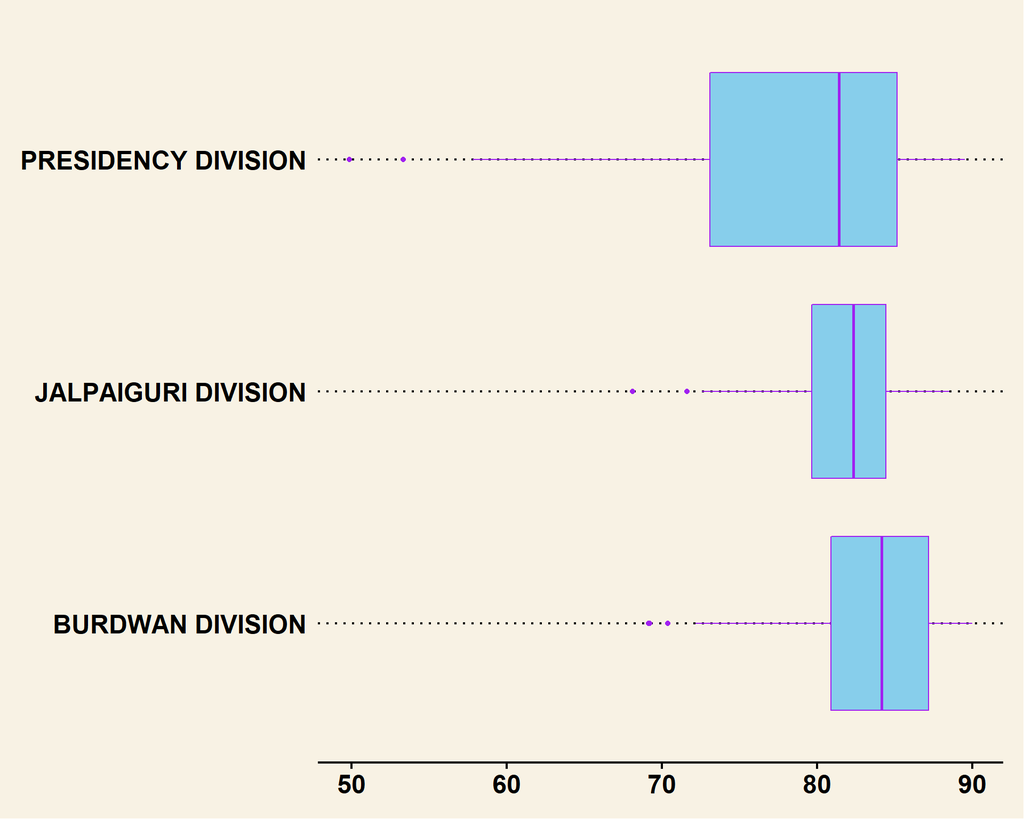

## Constituency with lower voter turnout

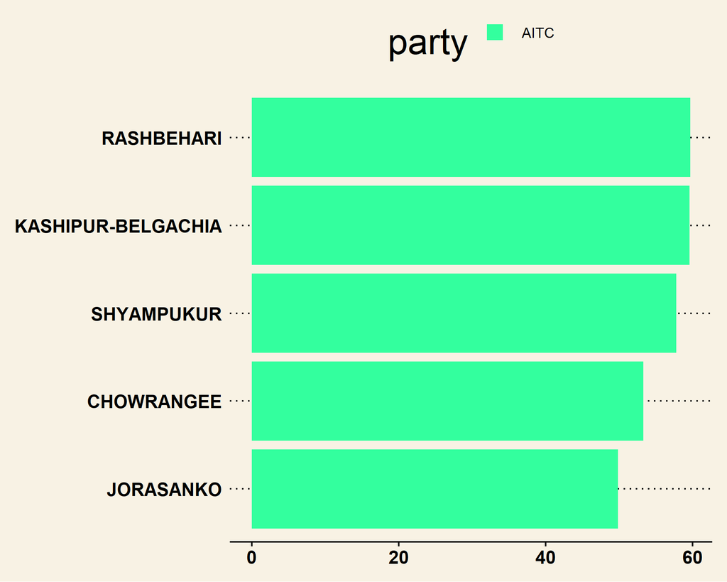

## Constituency with higher voter turnout

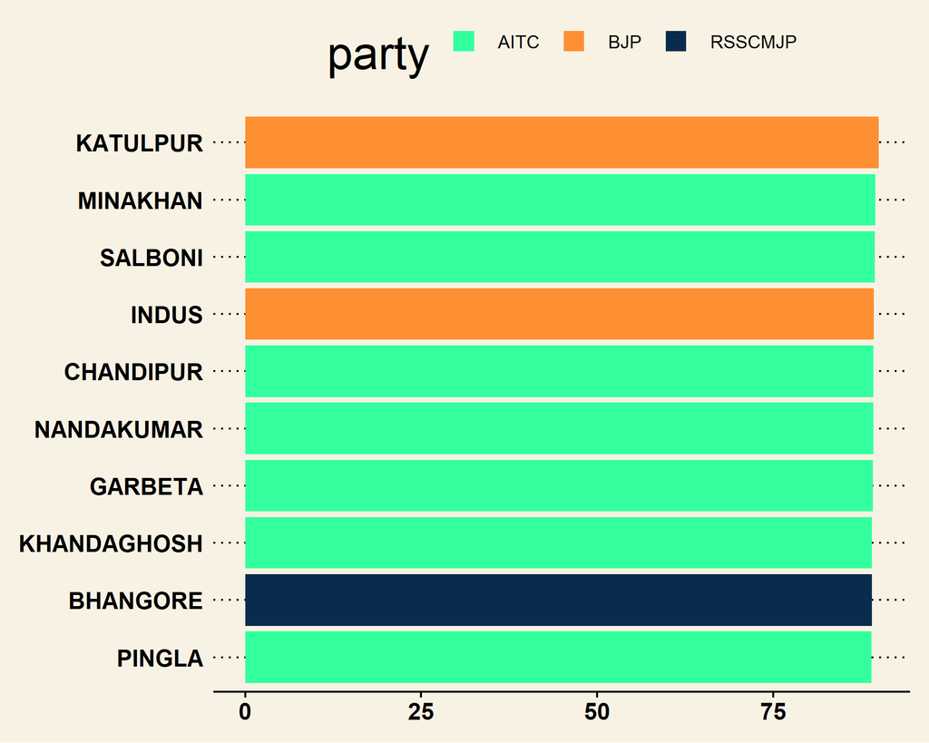

## The CM’s Constituency

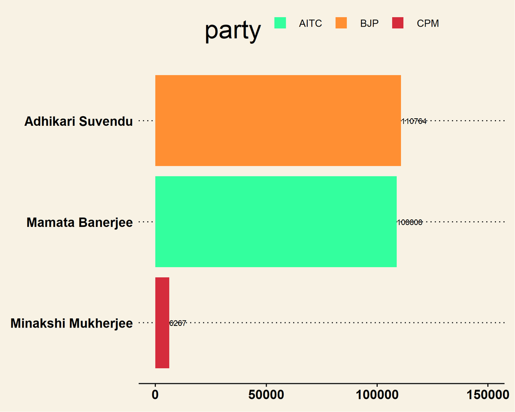

## Victory Margins across the seats and parties

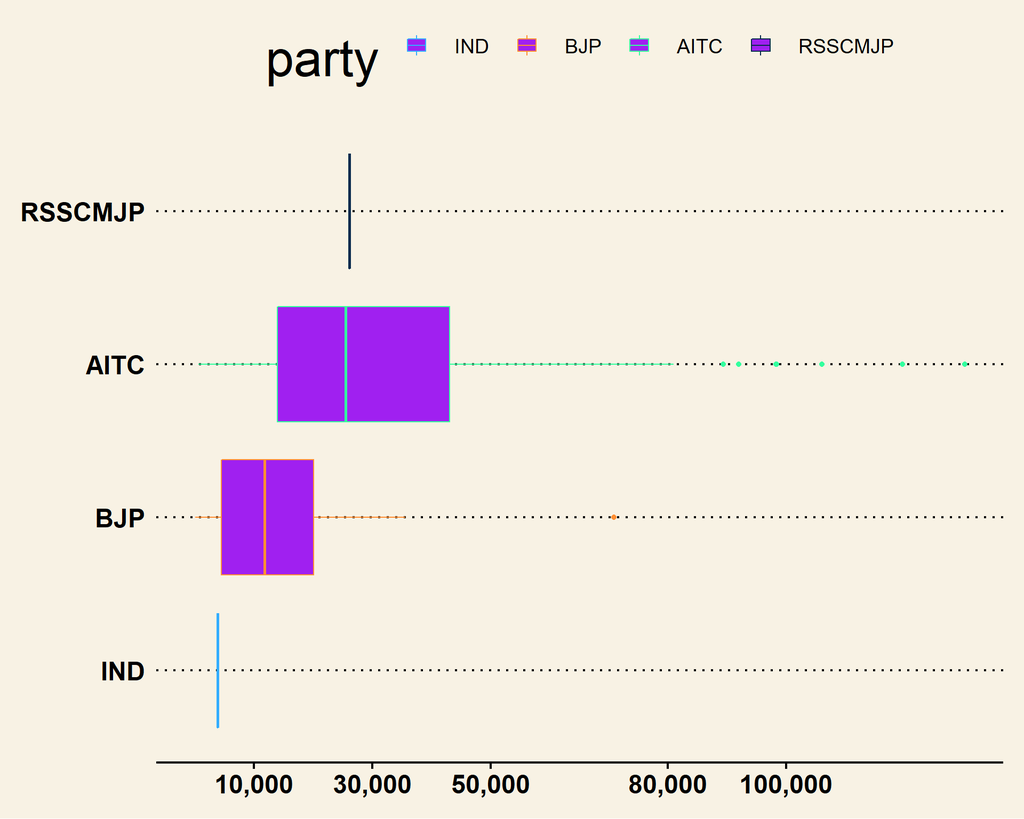

### References

### APA style

### Authors guidelines |

#### ADR